# INN_Learner_Notebook_Full_code

#### Model_2 Chosen

```python
# Save the model and history
model_2 = model_2B
history_2 = history_2B
```

**Loss function**

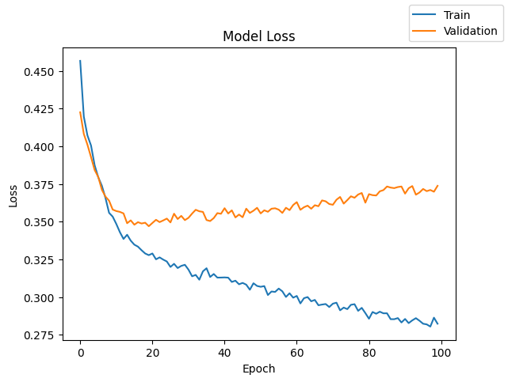

```python
plot(history_2, "loss")
```

**Recall**

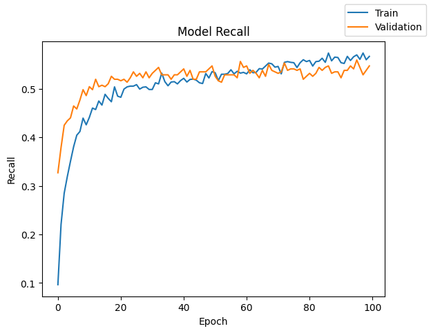

```python
plot(history_2, "recall")
```

**Accuracy**

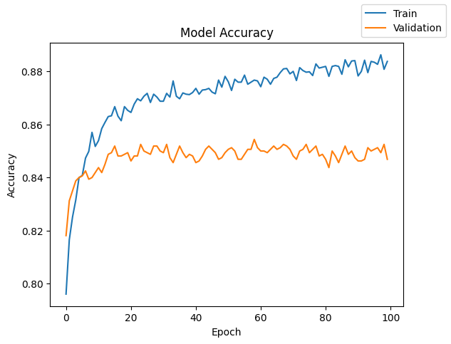

```python
plot(history_2, "accuracy")
```

```python
#Predicting the results using 0.5 as the threshold.
y_train_pred = model_2.predict(X_train)
y_train_pred = (y_train_pred > 0.5)
y_train_pred
```

```
200/200 ━━━━━━━━━━━━━━━━━━━━ 1s 6ms/step
```

```
array([[False],
       [ True],
       [False],
       ...,
       [False],
       [False],
       [ True]])
```

```python
#Predicting the results using 0.5 as the threshold.
y_val_pred = model_2.predict(X_val)
y_val_pred = (y_val_pred > 0.5)
y_val_pred
```

```
50/50 ━━━━━━━━━━━━━━━━━━━━ 0s 6ms/step
```

```
array([[False],
       [False],
       [False],
       ...,
       [False],
       [False],
       [False]])
```

**Classification report**

```python
#classification report
cr=classification_report(y_train,y_train_pred)
print(cr)
```

```
              precision    recall  f1-score   support

         0.0       0.92      0.95      0.93      5095
         1.0       0.79      0.65      0.71      1305

    accuracy                           0.89      6400
   macro avg       0.85      0.80      0.82      6400
weighted avg       0.89      0.89      0.89      6400
```

```python
#Performance Table on the model
model_performance_classification(model_2, X_train, y_train)
```

```
200/200 ━━━━━━━━━━━━━━━━━━━━ 0s 2ms/step
```

|  | Accuracy | Recall | Precision | F1 Score |
| --- | --- | --- | --- | --- |
| 0 | 0.893437 | 0.893437 | 0.889036 | 0.889659 |

```python
#classification report
cr = classification_report(y_val,y_val_pred)
print(cr)
```

```
              precision    recall  f1-score   support

         0.0       0.89      0.92      0.91      1273
         1.0       0.65      0.55      0.59       327

    accuracy                           0.85      1600
   macro avg       0.77      0.74      0.75      1600
weighted avg       0.84      0.85      0.84      1600
```

```python
#Performance Table on the model
model_performance_classification(model_2, X_val, y_val)
```

```
50/50 ━━━━━━━━━━━━━━━━━━━━ 0s 2ms/step
```

|  | Accuracy | Recall | Precision | F1 Score |
| --- | --- | --- | --- | --- |
| 0 | 0.846875 | 0.846875 | 0.839236 | 0.841903 |

**Confusion matrix**

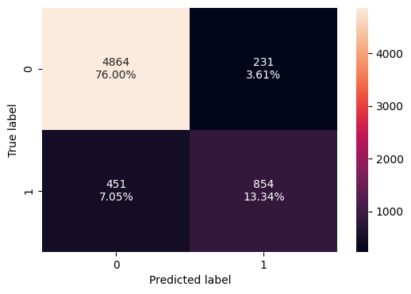

```python
#Calculating the confusion matrix
make_confusion_matrix(y_train, y_train_pred)
```

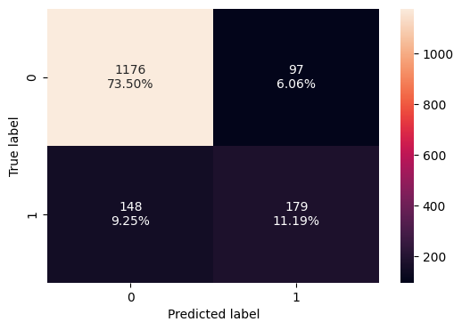

```python
#Calculating the confusion matrix
make_confusion_matrix(y_val, y_val_pred)
```

Results

```python
results.loc[2]= subresults.iloc[0]
results
```

|  | # neurons - input layer | activation function - input layer | # hidden layers | # neurons - hidden layer | activation function - hidden layer | # epochs | batch size | optimizer | learning rate | momentum | weight initializer | regularization | train loss | validation loss | train accuracy | validation accuracy | train recall | validation recall | recall diff | time (secs) |
| --- | --- | --- | --- | --- | --- | --- | --- | --- | --- | --- | --- | --- | --- | --- | --- | --- | --- | --- | --- | --- |
| 0 | 240 | tanh | 4 | [160, 64, 32, 240] | tanh | 100 | 32 | sgd | 0.028 | - | xavier | - | 0.316604 | 0.361055 | 0.871875 | 0.841875 | 0.509579 | 0.492355 | 0.017224 | 216.86 |
| 1 | 64 | relu | 1 | 64 | relu | 50 | 16 | adam | 0.001 | - | xavier | - | 0.317832 | 0.541532 | 0.870625 | 0.845625 | 0.512644 | 0.590214 | -0.07757 | 64.19 |
| 2 | 64 | relu | 1 | 64 | relu | 100 | 32 | adam | 0.001 | - | xavier | Dropout [0.2] | 0.282304 | 0.373828 | 0.88375 | 0.846875 | 0.56705 | 0.547401 | 0.019649 | 113.75 |

### Neural Network with Balanced Data (by applying SMOTE) and SGD Optimizer

```python
#Creating a pandas dataframe.
subresults = pd.DataFrame(columns=columns)
```

SMOTE/oversampling will be applied to balance the dataset

```python
os  = SMOTE(random_state=13)
X_train_over, y_train_over= os.fit_resample(X_train,y_train)
print('After Over Sampling, the shape of train_X: {}'.format(X_train_over.shape))
print('After Over Sampling, the shape of train_y: {} \n'.format(y_train_over.shape))
```

```
After Over Sampling, the shape of train_X: (10190, 11)
After Over Sampling, the shape of train_y: (10190,)
```

#### Model_3A/ Manual Tuning

```python
#Initialize batch size and epochs with each run; will update here if needed to optimize later on
batch_size = 32
epochs = 100
```

Let's build a model with the balanced dataset

```python
# clears the current Keras session, resetting all layers and models previously created, freeing up memory and resources.
tf.keras.backend.clear_session()
#Fixing the seed for random number generators so that we can ensure we receive the same output everytime
np.random.seed(13)
random.seed(13)
tf.random.set_seed(13)
```

```python
#Initializing the model
model_3A = Sequential()
#Inout Layer
model_3A.add(Dense(64,activation='relu',input_dim = X_train_over.shape[1]))
#Hidden Layer 1
model_3A.add(Dense(64,activation='relu'))
#Output Layer
model_3A.add(Dense(1, activation = 'sigmoid'))
```

```python
#Initate the optimizer
optimizer = tf.keras.optimizers.SGD(learning_rate=0.001)

# Metric of Signinificance to track is Recall
metricA = 'accuracy'
metricR = 'recall'
```

```python
# Compile the model with binary cross entropy as loss function and recall as the metric
model_3A.compile(loss='binary_crossentropy',optimizer=optimizer,metrics=[metricA, metricR])
```

Base Model Key Parameters:

- Batch Size 32
- Epochs 100
- Input Layer: 64 Neurons, Relu Activation
- Hidden Layer 1: 64 Neurons, Relu Activation
- Output Layer: 1 Neuron, Sigmoid Activation
- Optimizer: SGD, Learning Rate: 0.001
- Loss Function: Binary Cross Entropy

```python
#Print a summary of the key parameters of the NN model created
model_3A.summary()
```

```
Model: "sequential"
```

```
┏━━━━━━━━━━━━━━━━━━━━━━━━━━━━━━━━━━━━━━┳━━━━━━━━━━━━━━━━━━━━━━━━━━━━━┳━━━━━━━━━━━━━━━━━┓
┃ Layer (type)                         ┃ Output Shape                ┃         Param # ┃
┡━━━━━━━━━━━━━━━━━━━━━━━━━━━━━━━━━━━━━━╇━━━━━━━━━━━━━━━━━━━━━━━━━━━━━╇━━━━━━━━━━━━━━━━━┩
│ dense (Dense)                        │ (None, 64)                  │             768 │
├──────────────────────────────────────┼─────────────────────────────┼─────────────────┤
│ dense_1 (Dense)                      │ (None, 64)                  │           4,160 │
├──────────────────────────────────────┼─────────────────────────────┼─────────────────┤
│ dense_2 (Dense)                      │ (None, 1)                   │              65 │
└──────────────────────────────────────┴─────────────────────────────┴─────────────────┘
```

```
 Total params: 4,993 (19.50 KB)
```

```
 Trainable params: 4,993 (19.50 KB)
```

```
 Non-trainable params: 0 (0.00 B)
```

```python
#Running the Fit of the NN on the Train and Validation  Data and tracking the time taken

start = time.time()

history_3A = model_3A.fit(
    X_train_over, y_train_over,
    batch_size= batch_size,
    epochs= epochs,
    verbose=1,
    validation_data = (X_val,y_val)
)

end = time.time()
tt = end-start
print(f"Total training time: {tt} seconds")
```

```
319/319 ━━━━━━━━━━━━━━━━━━━━ 3s 5ms/step - accuracy: 0.4235 - loss: 0.7099 - recall: 0.6640 - val_accuracy: 0.4069 - val_loss: 0.7113 - val_recall: 0.6544
319/319 ━━━━━━━━━━━━━━━━━━━━ 2s 3ms/step - accuracy: 0.4858 - loss: 0.6953 - recall: 0.5889 - val_accuracy: 0.5537 - val_loss: 0.6883 - val_recall: 0.6239
319/319 ━━━━━━━━━━━━━━━━━━━━ 1s 3ms/step - accuracy: 0.5593 - loss: 0.6831 - recall: 0.5665 - val_accuracy: 0.6225 - val_loss: 0.6709 - val_recall: 0.6391
319/319 ━━━━━━━━━━━━━━━━━━━━ 2s 6ms/step - accuracy: 0.6093 - loss: 0.6723 - recall: 0.5865 - val_accuracy: 0.6644 - val_loss: 0.6569 - val_recall: 0.6391
319/319 ━━━━━━━━━━━━━━━━━━━━ 1s 3ms/step - accuracy: 0.6435 - loss: 0.6627 - recall: 0.6120 - val_accuracy: 0.6844 - val_loss: 0.6454 - val_recall: 0.6361
319/319 ━━━━━━━━━━━━━━━━━━━━ 1s 3ms/step - accuracy: 0.6606 - loss: 0.6541 - recall: 0.6355 - val_accuracy: 0.6956 - val_loss: 0.6360 - val_recall: 0.6453
319/319 ━━━━━━━━━━━━━━━━━━━━ 1s 2ms/step - accuracy: 0.6762 - loss: 0.6463 - recall: 0.6533 - val_accuracy: 0.6944 - val_loss: 0.6281 - val_recall: 0.6514
319/319 ━━━━━━━━━━━━━━━━━━━━ 1s 2ms/step - accuracy: 0.6858 - loss: 0.6392 - recall: 0.6665 - val_accuracy: 0.6956 - val_loss: 0.6213 - val_recall: 0.6575
319/319 ━━━━━━━━━━━━━━━━━━━━ 1s 2ms/step - accuracy: 0.6943 - loss: 0.6326 - recall: 0.6747 - val_accuracy: 0.6994 - val_loss: 0.6153 - val_recall: 0.6544
319/319 ━━━━━━━━━━━━━━━━━━━━ 1s 2ms/step - accuracy: 0.6997 - loss: 0.6265 - recall: 0.6818 - val_accuracy: 0.7038 - val_loss: 0.6100 - val_recall: 0.6575
319/319 ━━━━━━━━━━━━━━━━━━━━ 1s 2ms/step - accuracy: 0.7038 - loss: 0.6209 - recall: 0.6872 - val_accuracy: 0.6994 - val_loss: 0.6053 - val_recall: 0.6544
319/319 ━━━━━━━━━━━━━━━━━━━━ 1s 2ms/step - accuracy: 0.7083 - loss: 0.6157 - recall: 0.6957 - val_accuracy: 0.7000 - val_loss: 0.6011 - val_recall: 0.6483
319/319 ━━━━━━━━━━━━━━━━━━━━ 1s 2ms/step - accuracy: 0.7134 - loss: 0.6109 - recall: 0.7039 - val_accuracy: 0.7038 - val_loss: 0.5974 - val_recall: 0.6544
319/319 ━━━━━━━━━━━━━━━━━━━━ 1s 2ms/step - accuracy: 0.7154 - loss: 0.6065 - recall: 0.7054 - val_accuracy: 0.7056 - val_loss: 0.5941 - val_recall: 0.6544
319/319 ━━━━━━━━━━━━━━━━━━━━ 1s 2ms/step - accuracy: 0.7172 - loss: 0.6024 - recall: 0.7087 - val_accuracy: 0.7081 - val_loss: 0.5910 - val_recall: 0.6606
319/319 ━━━━━━━━━━━━━━━━━━━━ 1s 2ms/step - accuracy: 0.7183 - loss: 0.5986 - recall: 0.7093 - val_accuracy: 0.7125 - val_loss: 0.5882 - val_recall: 0.6697
319/319 ━━━━━━━━━━━━━━━━━━━━ 2s 5ms/step - accuracy: 0.7192 - loss: 0.5951 - recall: 0.7099 - val_accuracy: 0.7119 - val_loss: 0.5857 - val_recall: 0.6697
319/319 ━━━━━━━━━━━━━━━━━━━━ 2s 3ms/step - accuracy: 0.7210 - loss: 0.5919 - recall: 0.7125 - val_accuracy: 0.7144 - val_loss: 0.5833 - val_recall: 0.6697
319/319 ━━━━━━━━━━━━━━━━━━━━ 1s 3ms/step - accuracy: 0.7239 - loss: 0.5889 - recall: 0.7175 - val_accuracy: 0.7181 - val_loss: 0.5811 - val_recall: 0.6697
319/319 ━━━━━━━━━━━━━━━━━━━━ 1s 2ms/step - accuracy: 0.7264 - loss: 0.5862 - recall: 0.7199 - val_accuracy: 0.7200 - val_loss: 0.5790 - val_recall: 0.6697
319/319 ━━━━━━━━━━━━━━━━━━━━ 1s 2ms/step - accuracy: 0.7275 - loss: 0.5837 - recall: 0.7227 - val_accuracy: 0.7188 - val_loss: 0.5771 - val_recall: 0.6636
319/319 ━━━━━━━━━━━━━━━━━━━━ 1s 2ms/step - accuracy: 0.7280 - loss: 0.5814 - recall: 0.7241 - val_accuracy: 0.7188 - val_loss: 0.5753 - val_recall: 0.6636
319/319 ━━━━━━━━━━━━━━━━━━━━ 1s 2ms/step - accuracy: 0.7283 - loss: 0.5792 - recall: 0.7237 - val_accuracy: 0.7219 - val_loss: 0.5736 - val_recall: 0.6667
319/319 ━━━━━━━━━━━━━━━━━━━━ 2s 4ms/step - accuracy: 0.7298 - loss: 0.5772 - recall: 0.7268 - val_accuracy: 0.7225 - val_loss: 0.5720 - val_recall: 0.6667
319/319 ━━━━━━━━━━━━━━━━━━━━ 1s 2ms/step - accuracy: 0.7316 - loss: 0.5753 - recall: 0.7296 - val_accuracy: 0.7225 - val_loss: 0.5704 - val_recall: 0.6667
319/319 ━━━━━━━━━━━━━━━━━━━━ 1s 2ms/step - accuracy: 0.7329 - loss: 0.5736 - recall: 0.7313 - val_accuracy: 0.7237 - val_loss: 0.5690 - val_recall: 0.6697
```

[output cut: 75 more lines]

```python
#Performance Table on the model
model_performance_classification(model_3A, X_train, y_train)
```

```
200/200 ━━━━━━━━━━━━━━━━━━━━ 0s 1ms/step
```

|  | Accuracy | Recall | Precision | F1 Score |
| --- | --- | --- | --- | --- |
| 0 | 0.720938 | 0.720938 | 0.81242 | 0.745727 |

```python
#Performance Table on the model
model_performance_classification(model_3A, X_val, y_val)
```

```
50/50 ━━━━━━━━━━━━━━━━━━━━ 0s 1ms/step
```

|  | Accuracy | Recall | Precision | F1 Score |
| --- | --- | --- | --- | --- |
| 0 | 0.72375 | 0.72375 | 0.802783 | 0.746909 |

Base Model Key Parameters:

- Batch Size 32
- Epochs 100
- Input Layer: 64 Neurons, Relu Activation
- Hidden Layer 1: 64 Neurons, Relu Activation
- Output Layer: 1 Neuron, Sigmoid Activation
- Optimizer: SGD, Learning Rate: 0.001
- Loss Function: Binary Cross Entropy

```python
# #Clear subresults index to update parameters information
# subresults.drop(subresults.index[0], inplace=True)
#Enter in new parameter and performance information
subresults.loc[0] = [64,"relu", 1, 64, "relu", 100, 32, "sgd", 0.001, "-", "xavier", "-",
          history_3A.history["loss"][-1], history_3A.history["val_loss"][-1],
          history_3A.history["accuracy"][-1], history_3A.history["val_accuracy"][-1], history_3A.history['recall'][-1],
          history_3A.history['val_recall'][-1], history_3A.history['recall'][-1] - history_3A.history['val_recall'][-1],
          round(tt, 2)]
subresults
```

|  | # neurons - input layer | activation function - input layer | # hidden layers | # neurons - hidden layer | activation function - hidden layer | # epochs | batch size | optimizer | learning rate | momentum | weight initializer | regularization | train loss | validation loss | train accuracy | validation accuracy | train recall | validation recall | recall diff | time (secs) |
| --- | --- | --- | --- | --- | --- | --- | --- | --- | --- | --- | --- | --- | --- | --- | --- | --- | --- | --- | --- | --- |
| 0 | 64 | relu | 1 | 64 | relu | 100 | 32 | sgd | 0.001 | - | xavier | - | 0.516398 | 0.521228 | 0.746614 | 0.72375 | 0.779392 | 0.706422 | 0.07297 | 133.56 |